# Weekly Energy Charts

May 06, 2022

[Sign up here to get on our email list](https://docs.google.com/forms/d/e/1FAIpQLSckqeGjUvIlhveVyjmkXe913tzQRLANqPNQzEZTUQD2hQxH8g/viewform?usp=pp_url)

# Featured Stories

## India’s appetite for Russian crude

#### [Debosree Mukherjee](https://www.linkedin.com/in/debosree-mukherjee/)

Western sanctions following Russia’s invasion of Ukraine pushed Russian crude into record low prices against other grades. India, the third-largest oil importer, called for an immediate ceasefire in Ukraine but has not explicitly condemned Russia’s actions. Indian refiners took this opportunity to snap up Russian crude at a discounted price.

[According to Bloomberg](https://www.bloomberg.com/news/articles/2022-05-04/india-wants-russia-to-discount-its-oil-to-less-than-70-a-barrel), between state and private refiners, India has bought more than 40 million barrels of Russian crude since February 24, 2022. That’s 20% more than Russia-to-India flows for all of 2021. India is trying to get deeper discounts and seeking cargoes at less than $70 a barrel to compensate for the risks of buying from Russia amidst western sanctions. Global benchmark Brent is currently trading near $105 a barrel. India’s top refiners are negotiating a 6 month deal to import [around half a million barrels a day](https://www.bloomberg.com/news/videos/2022-05-02/russia-india-in-negotiations-on-crude-oil-deal-video) from Russia starting in June.

India’s oil minister defended the increased oil imports from Russia stating that the purchases are a fraction of the overall annual need and the government does not intervene in the refiners’ import deals. [Times of India](https://timesofindia.indiatimes.com/business/india-business/indian-refiners-seeking-6-month-russian-oil-import-deal-report/articleshow/91178468.cms) reported that the state-run energy companies are also evaluating the possibility of buying BP’s stake in Russian energy company Rosneft.

## New Hope for Canadian LNG Projects?

#### [Erica Beattie](https://www.linkedin.com/in/erica-beattie-594b471a1/)

The global [liquified natural gas (LNG)](https://www.lngcanada.ca/about-lng-canada/lng-101/) market is poised to grow dramatically. Dramatic increases in natural gas prices in Europe and Asia are creating optimism among suppliers that has been missing since the early-2010s.

[figure not shown]

Gas and LNG Prices Increases in 2021

The long-term demand outlook is also [robust](https://www.shell.com/energy-and-innovation/natural-gas/liquefied-natural-gas-lng/lng-outlook-2022.html#iframe=L3dlYmFwcHMvTE5HX291dGxvb2tfMjAyMi8), although there are stark differences in forecasts of LNG’s role in a carbon-constrained world. LNG presents an economic opportunity for Canada, with Shell’s LNG Canada project under construction, [Woodfibre LNG](https://www.canadianenergycentre.ca/extra-low-ghg-canadian-lng-project-gets-the-green-light/) beginning construction, and a major expansion of LNG Canada plant under consideration.

[figure not shown]

Shell LNG Outlook

Major [current events](https://www.mckinsey.com/industries/oil-and-gas/our-insights/petroleum-blog/reflecting-on-2021-global-lng-and-european-pipeline-flows) such as the COVID-19 pandemic and Russia’s invasion of Ukraine have had tremendous impacts on the outlook for LNG. Canada’s LNG industry has a unique value proposition owing to its potential to use of hydroelectricity to drive liquefaction, enhancing potential opportunities to reduce emissions through fuel switching. With the Glasgow climate conference in the rear-view mirror, there remains some pontential for [Article 6 credits](https://www.iisd.org/articles/paris-agreement-article-6-rules) for LNG production and export in the context of a bilateral arrangement.

## Ozone may be heating the planet more than we realize

#### [Keshinee Moonian](https://www.linkedin.com/in/keshineemoonian/)

Changes to ozone levels in the atmosphere accounted for almost ⅓ of the warming seen in ocean waters bordering Antarctica in the second half of the 20th century. This rapid and severe warming affects the Southern Ocean’s role in soaking up excess heat as the planet warms.

The majority of this warming was the result of ozone increases in the lower atmosphere. Dr Michaela Hegglin, an Associate Professor in atmospheric chemistry, explains that “ozone close to Earth’s surface is harmful to people and the environment, but this study reveals it also has a big impact on the ocean’s ability to absorb excess heat from the atmosphere.”

In the upper atmosphere, ozone is formed by the interaction between oxygen molecules and the sun’s UV rays. It is created, in the lower atmosphere, due to chemical reactions between pollutants like vehicle exhaust fumes and other emissions. It’s a component of smog.

An international team of scientists, led by the University of California Riverside, conducted new research where models were used to simulate changes in ozone levels in the upper and lower atmosphere between 1955 and 2000. It was found that the increased ozone in the lower atmosphere caused 60% of the overall ozone-induced warming in the Southern Ocean during that period – a lot more than was expected previously.

The ozone layer is vital since it filters harmful UV radiation from reaching Earth’s surface. Yet, “our research has shown that ozone increases in the lower atmosphere due to air pollution, which occurs primarily in the Northern Hemisphere and ‘leaks’ into the Southern Hemisphere, is a serious problem as well”, says Dr Hegglin.

However, “there is hope to find solutions, and the success of the Montreal Protocol at cutting CFC use shows that international action is possible to prevent damage to the planet.”

[Ozone may be heating the planet more than we realize](https://www.sciencedaily.com/releases/2022/03/220331121243.htm)

## It’s a dry (but not windy) cold

#### Andrew Leach

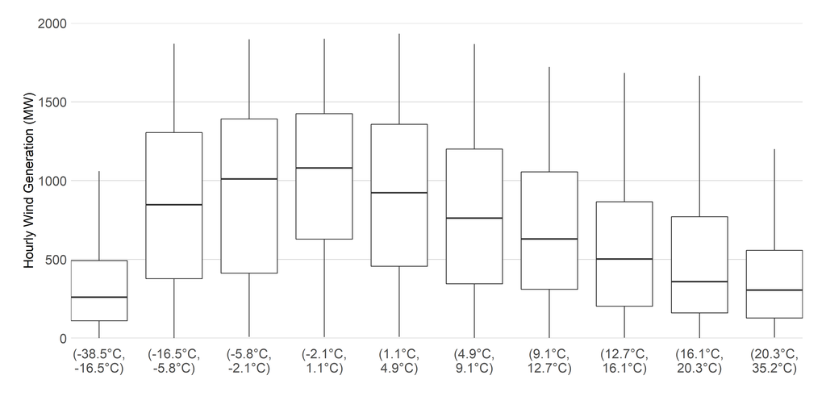

In the context of another research project I’m working on, I built this graph that I hope some of you will interesting – it captures both the variability of Alberta’s wind power generation and its relationship to temperatures. The box-plot shows that, no matter what the temperature, wind generation varies significantly (the boxes represent the 25th to 75th percentile of hourly generation in each temperature bin). More importantly, I think, the graph shows how low wind generation hours are much more likely when it’s really cold or really hot than at any other time. On the positive side though, wind generation is winter-peaking, at the time when Alberta’s electricity load is higher on average.

# Oil

## Weekly Crude Prices

### Feature Crude

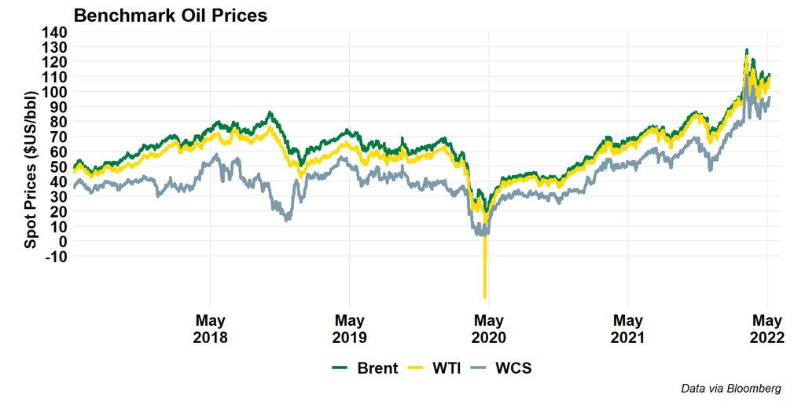

### Alberta Crude

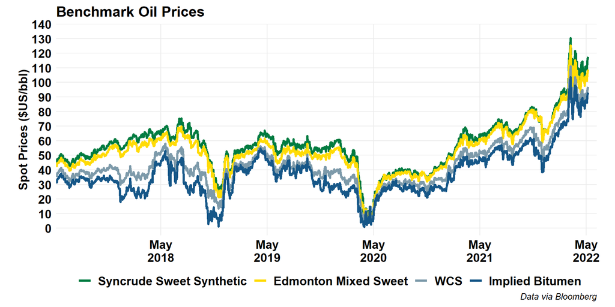

### US Crude

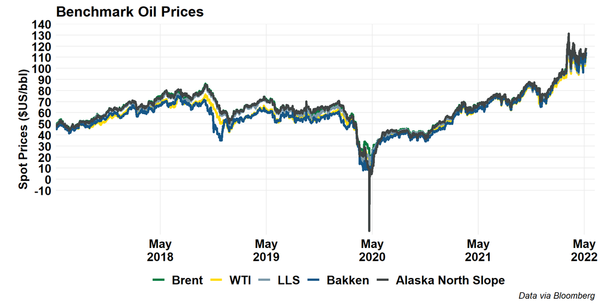

### Global Crude

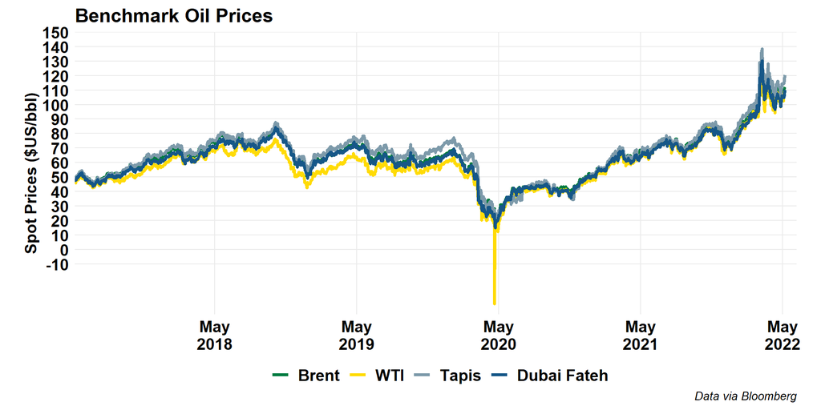

## Oil Price Differentials

### Brent-WTI

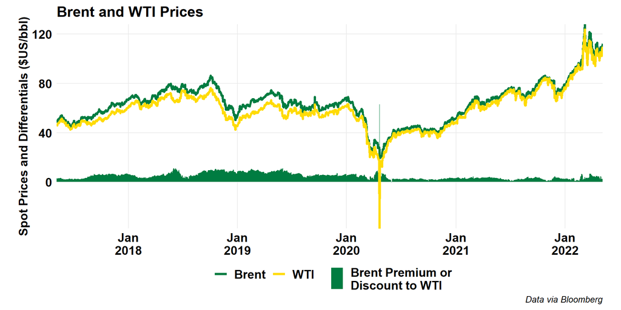

### WTI-WCS

[figure not shown]

### Maya-WCS

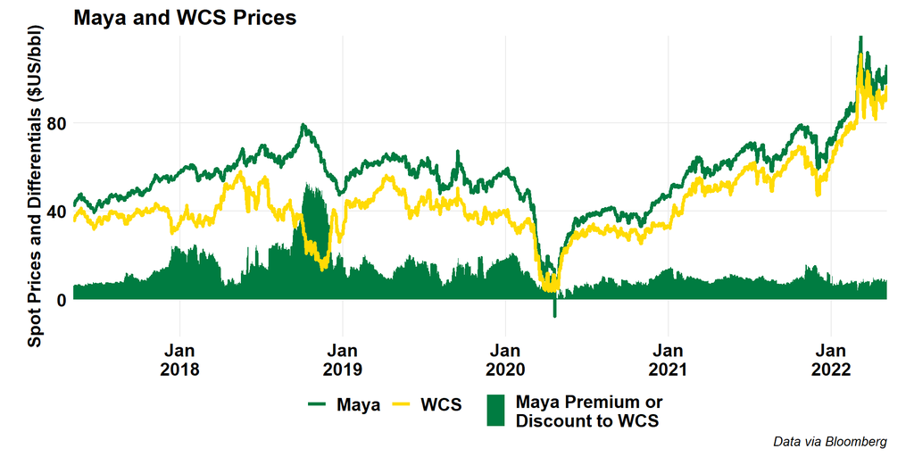

### WTI Cushing vs MEH

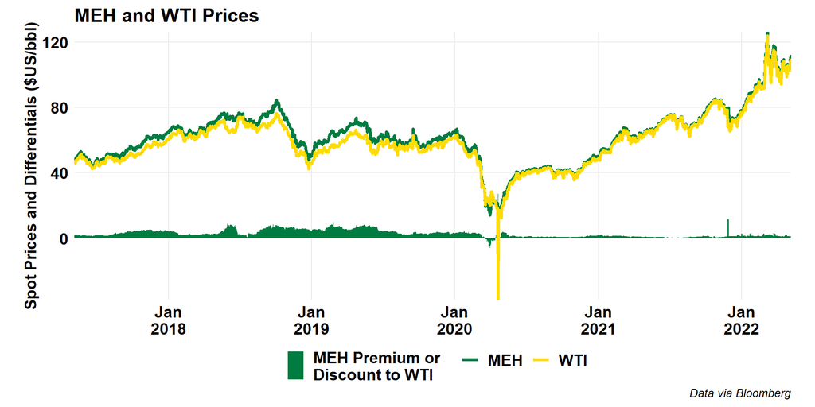

## EIA Petroleum Status Report

### Crude Oil Production

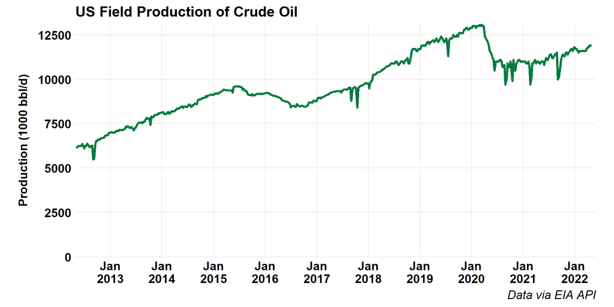

### Net Crude Oil Imports

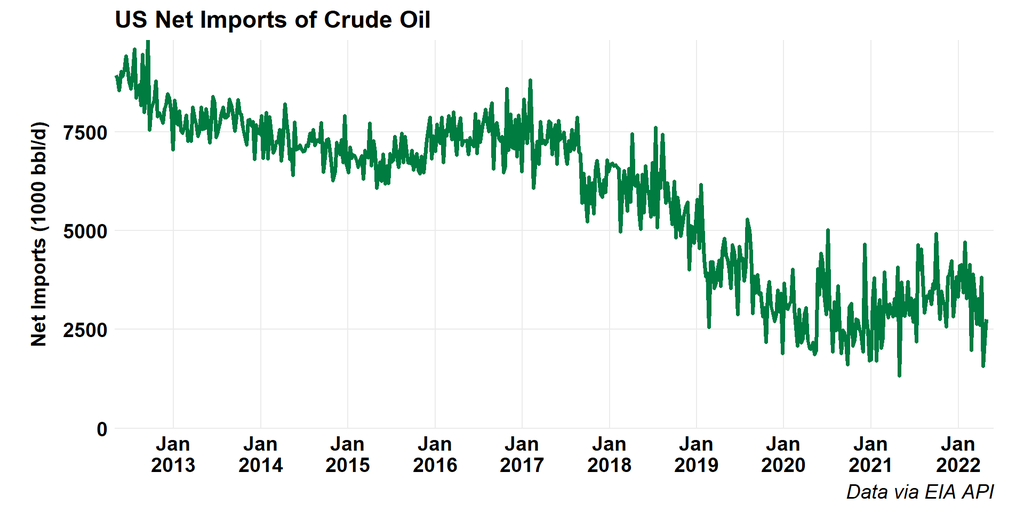

### Net Imports of Crude Oil and Products

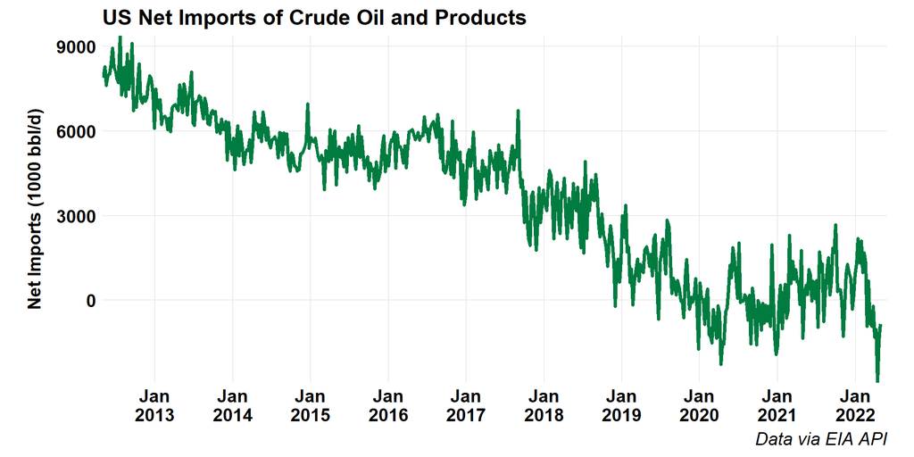

### Crude Inventories

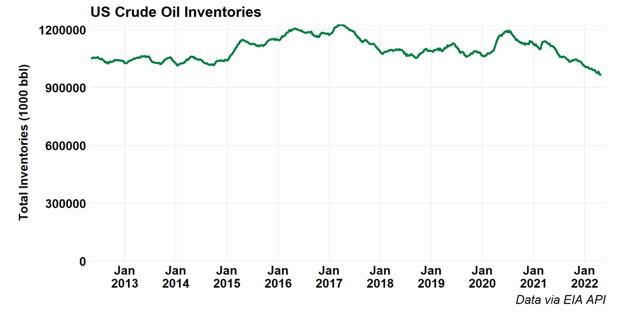

## Forward Curves

### WTI

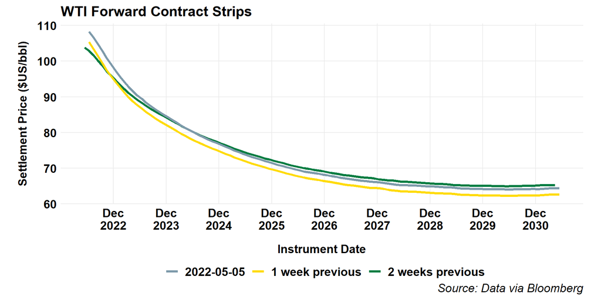

### Brent

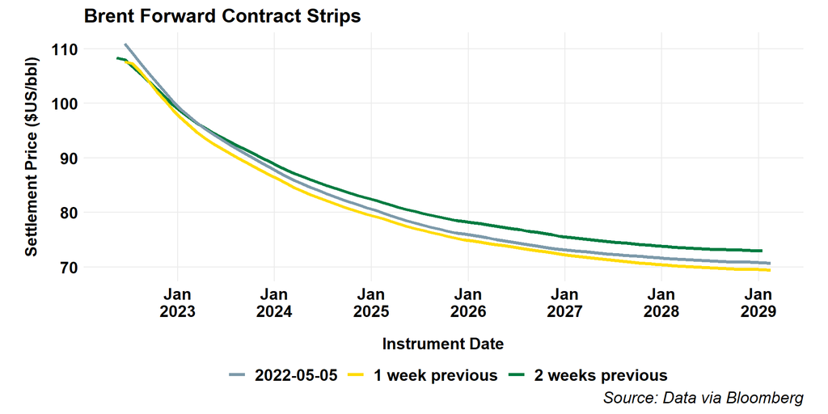

## Canadian Crude Exports

### Crude by Rail Exports

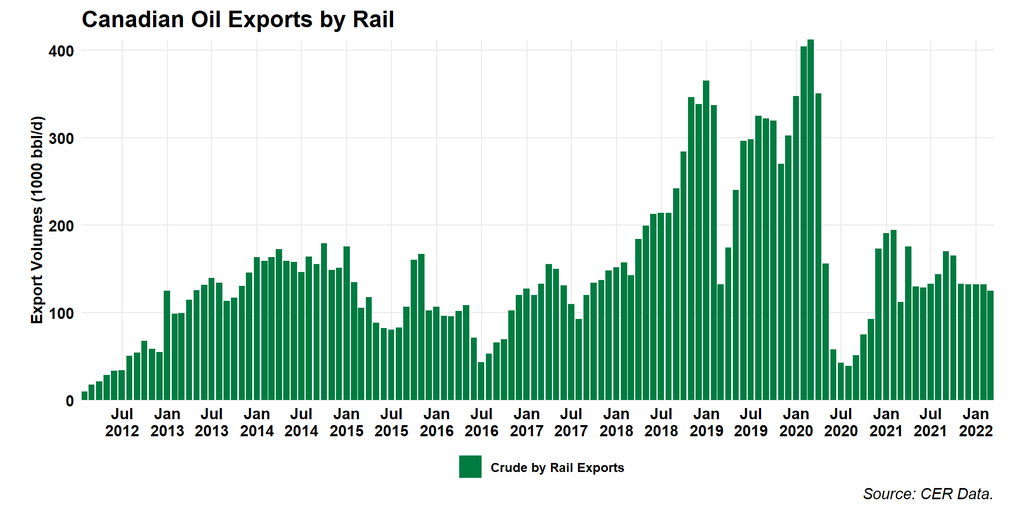

# Refined Products

## Canadian Gasoline Prices

### Map

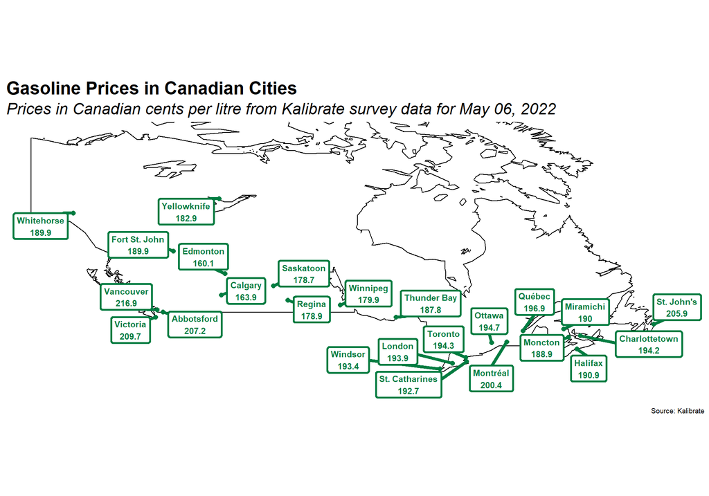

### Historic Gasoline Prices

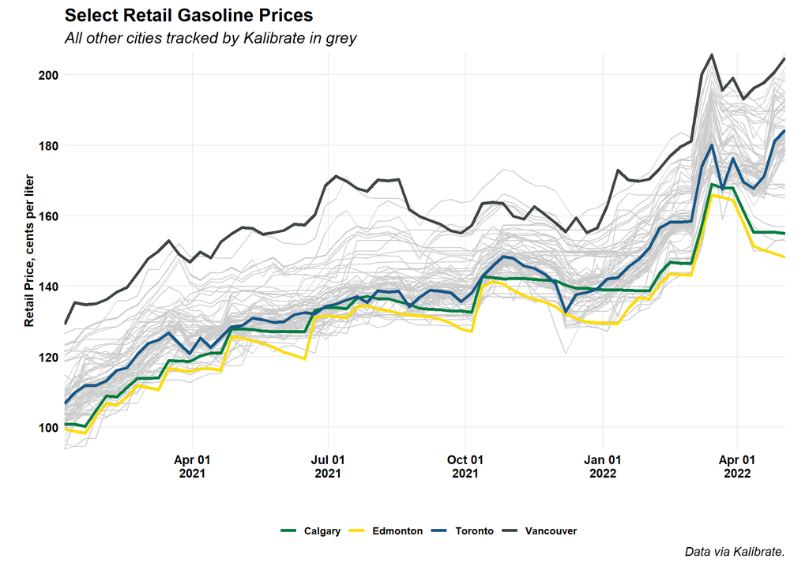

### Historic Diesel Prices

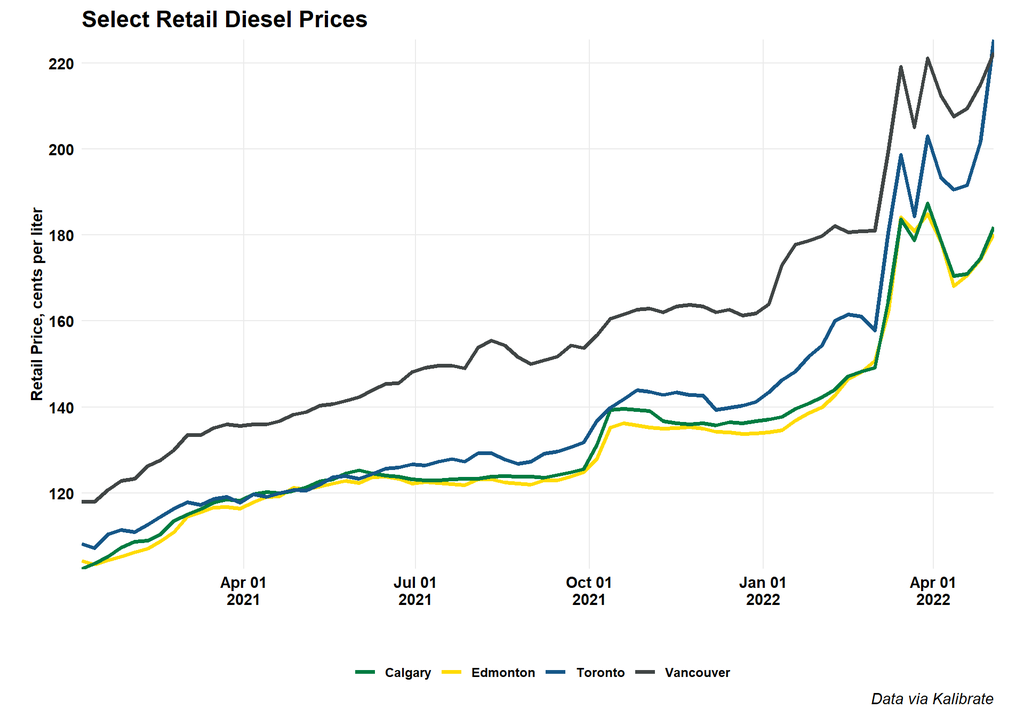

## Canadian Refinery Runs

### Canadian Refinery Runs

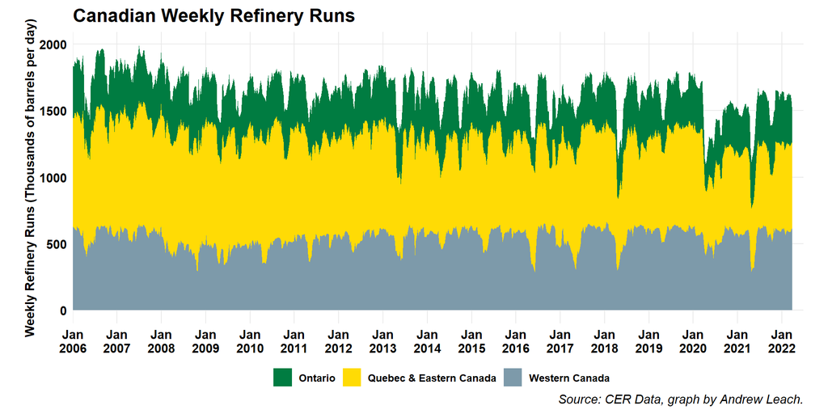

### Western Canada Refinery Runs

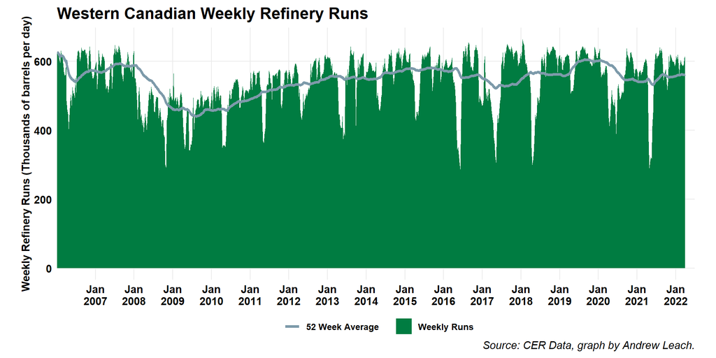

# Natural Gas

## Natural Gas Market Summary

### Feature Gas

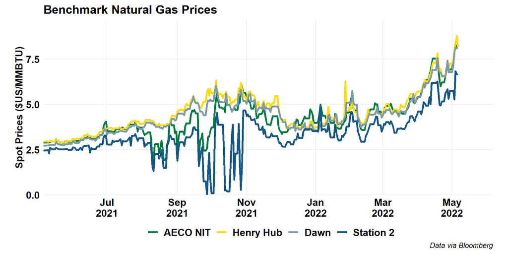

### Global Gas

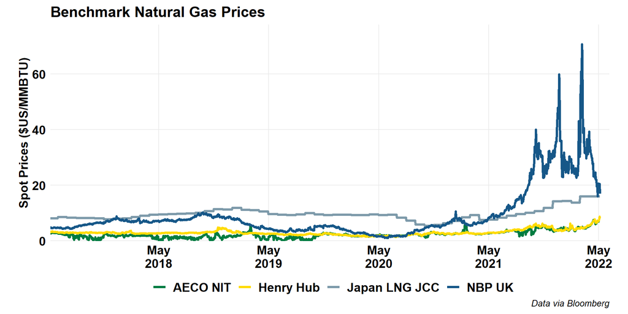

### North American Gas Hubs

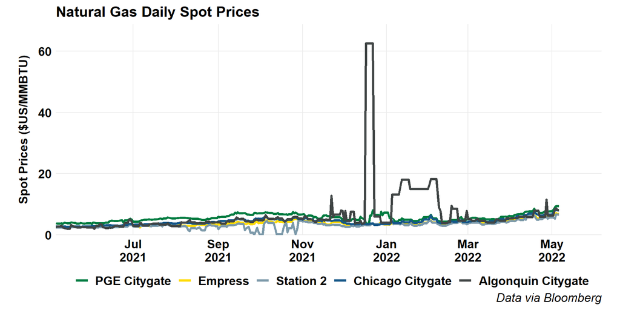

## Forward Prices

### Henry Hub

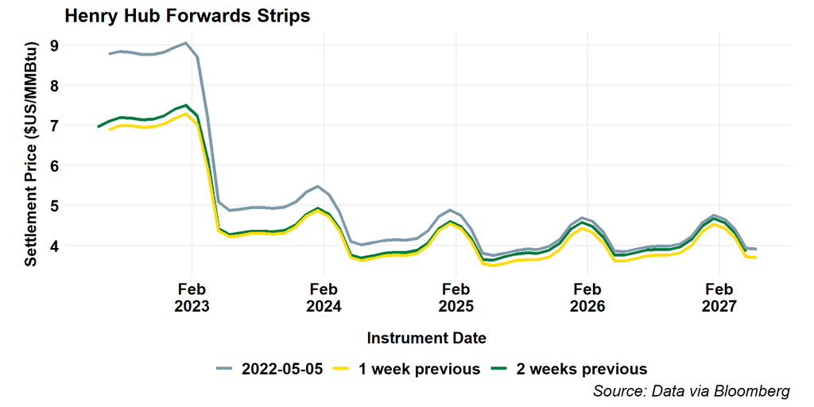

### Alberta (NIT) ($CAD)

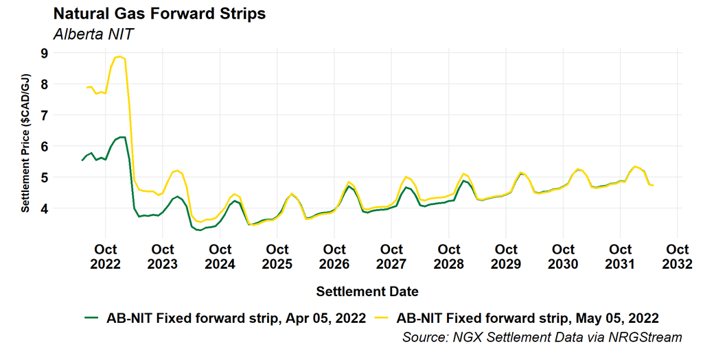

### Alberta (NIT)

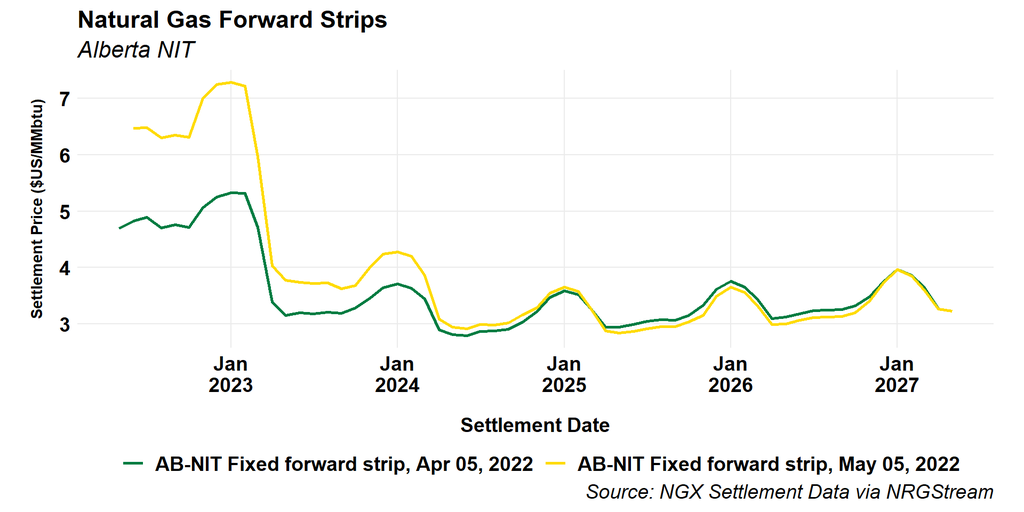

### BC (Stn 2)

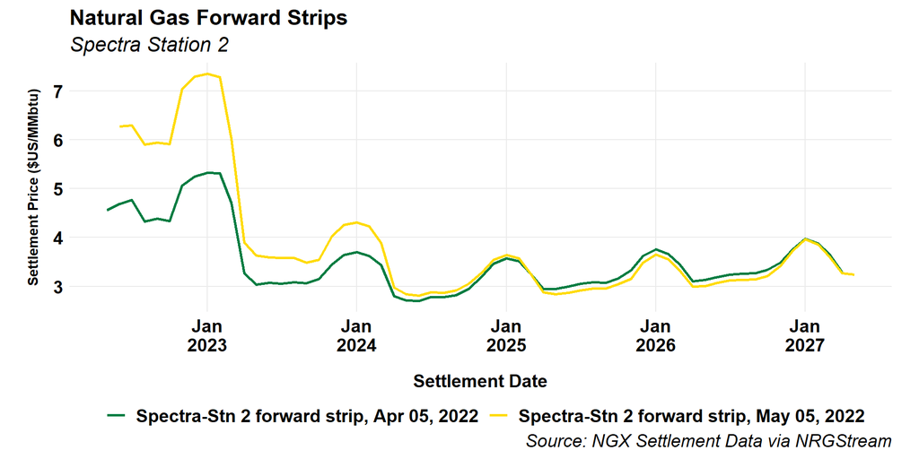

### Ontario (Dawn)

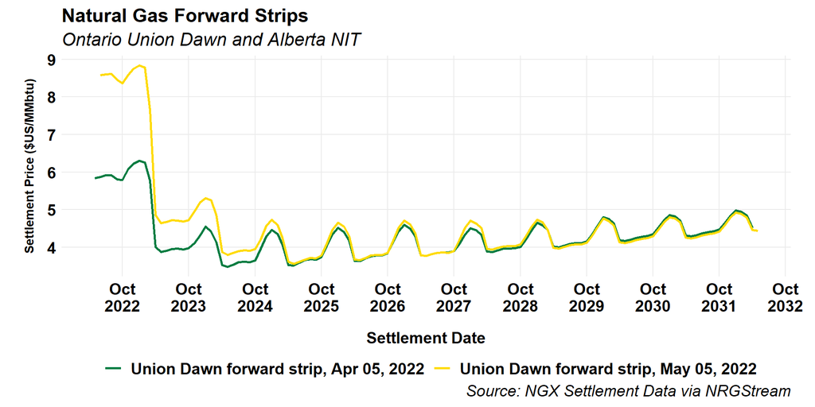

## EIA US Natural Gas Storage

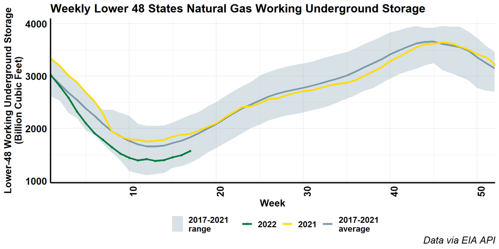